# Homework 1 Solutions

## Required libraries

```r
library(tidyverse)
library(tidycensus)
library(flextable)
```

Use the [FiveThirtyEight presidential elections data](https://raw.githubusercontent.com/fivethirtyeight/election-results/main/election_results_presidential.csv) to answer the following questions about the 2020 general election results.

Remember that you can load this from R by running:

```r
url<-"https://raw.githubusercontent.com/fivethirtyeight/election-results/main/election_results_presidential.csv"
presidential_elections<-read_csv(url)
```

## Question 1

Create a data frame with the two party vote share and the winning candidate for each state (plus D.C.) in the 2020 presidential election. Your results should have 51 rows and will look something like this (use whatever column names you like)

| State | Donald Trump | Joe Biden |
| --- | --- | --- |
| Alabama | 1441170 | 849624 |
| Alaska | 189951 | 153778 |
| Arizona | 1661686 | 1672143 |
| Arkansas | 760647 | 423932 |

```r
# Q1
voteshares <-presidential_elections|>
  filter(office_name=="U.S. President" & cycle==2020 & stage=="general")|>
  filter(candidate_name %in% c("Joe Biden", "Donald Trump"))|>
  filter(!str_detect(state, " CD-\\d+"))|>
  group_by(state, candidate_name)|>
  summarise(votes=sum(votes,na.rm =T))|>
  pivot_wider(names_from = candidate_name, values_from = votes)

voteshares|>
  slice_head(n=10)
```

| state | Donald Trump | Joe Biden |
| --- | --- | --- |
| Alabama | 1441170 | 849624 |
| Alaska | 189951 | 153778 |
| Arizona | 1661686 | 1672143 |
| Arkansas | 760647 | 423932 |
| California | 6006429 | 11110250 |
| Colorado | 1364607 | 1804352 |
| Connecticut | 714717 | 1080831 |
| Delaware | 200603 | 296268 |
| District of Columbia | 18586 | 317323 |
| Florida | 5668731 | 5297045 |

[output cut: 41 more lines]

## Question 2

Use the data frame you created in the prior step to calculate Biden’s share of the two-party vote in each state (i.e. Biden votes / (Biden votes + Trump votes)

```r
# Q2

voteshares<-voteshares|>
    mutate(`Biden Share`=`Joe Biden`/(`Joe Biden`+`Donald Trump`))
```

## Question 3

Use the following code to download the ACS estimated median household income for each state and then use a join to add this column to your data.

```r
median_income <- get_acs(geography = "state",
                         variables = c(median_income = "B19013_001"),
                         year = 2020)
```

(note that the “estimate” column will be the estimated median income)

```r
#Q3
voteshares_with_incomes <- voteshares|>
  left_join(median_income, by=join_by(state == NAME))
```

## Question 4

Run a linear regression to calculate the effect of median income on Biden’s statewide two party vote share. Produce a formatted table to display your results and briefly discuss your findings.

Submit your response and R code in a nicely formatted R markdown file, or in a document with formatted code in a separate section.

**Note**

Our measure of statewide median income is reporting in dollars, and our measure of Biden’s vote share is in proportions instead of percentages. It can be helpful for interpretation to convert median income into thousands of dollars and/or convert vote proportion into percentages. This won’t change any of the statistical findings, but these larger increments may be easier for people to interpret.

```r
# Q4

voteshares_with_incomes<-voteshares_with_incomes|>
  # creating income in 1,000 increments
  mutate(income_1k = estimate/1000,
         `Biden percent` = `Biden Share` *100
         )

model <- lm(`Biden percent` ~ income_1k,

            data = voteshares_with_incomes)


as_flextable(model)
```

|  | Estimate | Standard Error | t value | Pr(>\|t\|) |  |
| --- | --- | --- | --- | --- | --- |
| (Intercept) | -2.203 | 7.327 | -0.301 | 0.7650 |  |
| income_1k | 0.798 | 0.111 | 7.183 | 0.0000 | *** |

Signif. codes: 0 <= '***' < 0.001 < '**' < 0.01 < '*' < 0.05  
Residual standard error: 8.681 on 49 degrees of freedom  
Multiple R-squared: 0.5129, Adjusted R-squared: 0.503  
F-statistic: 51.6 on 49 and 1 DF, p-value: 0.0000

The $R^2$ value suggests that variation in income explains about half of the variation in Biden’s two-party vote share.

### Plot it:

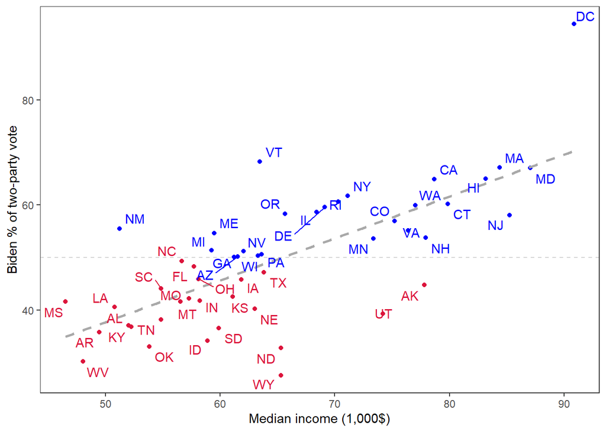

```r
library(ggrepel)
dc<-data.frame(state = "District of Columbia" , abb = "DC")
states_table<-data.frame("state" = state.name, "abb"= state.abb)|>
  bind_rows(dc)
voteshares_with_incomes<-
  voteshares_with_incomes|>
  left_join(states_table, by=join_by(state ==state))
ggplot(voteshares_with_incomes,
       aes(x = income_1k,
           y =`Biden percent`,
           label = abb,

           )
       ) +
  geom_hline(yintercept = 50, color='lightgrey', lty=2) +
  geom_point(aes(color  = `Biden percent` > 50))+
  geom_smooth(method='lm', color='darkgrey', lty=2, se=FALSE) +
  geom_text_repel(aes(color  = `Biden percent` > 50)) +
  theme_bw() +
  xlab("Median income (1,000$)") +
  ylab("Biden % of two-party vote") +
  scale_color_manual(guide='none', values=c('#DC143C', 'blue'))  +
  theme( panel.grid.major = element_blank(),
         panel.grid.minor = element_blank()
    )
```

### Alternatives to flextable

`huxreg` from the huxtable package gives access to some additional options for things like reporting other stats:

```r
library(huxtable)
huxreg("Model 1" = model,
       ci_level = .95,                                        # display 95 % CI
        error_format = "[{conf.low}, {conf.high}]",
       stars= NULL,                                           # remove p.value stars
       statistics = c(
         "N. obs." = "nobs",                                  # Add BIC
         "R squared" = "r.squared",
         "BIC" = "BIC"
       ),

       coefs = c(
         "Intercept" = "(Intercept)",                         # rename coefficients
         "Median income ($1,000)" = 'income_1k'),
       note ="Note: 95% confidence intervals in brackets"     # add a note
       )
```

|  | Model 1 |
| --- | --- |
| Intercept | -2.203 |
|  | [-16.927, 12.521] |
| Median income ($1,000) | 0.798 |
|  | [0.575, 1.021] |
| N. obs. | 51 |
| R squared | 0.513 |
| BIC | 374.919 |
| Note: 95% confidence intervals in brackets |  |

The `modelsummary` package is another alternative that works well with some of the other tools and packages we’ll use in this class. Here’s an example of showing the same model with some minor rearrangements:

```r
library(modelsummary)
models<-list("Model 1" = model)
cmap = c('income_1k' ="Median income ($1,000)",
           "(Intercept)" = "Constant"
         )

msum<-modelsummary(models,
             shape = term ~ statistic , # coefficients/CIs in wide format
             estimate  = "{estimate}",
             statistic ='conf.int',
             conf_level = .95,
             coef_map = cmap,                     # renaming/reordering coefficients
             gof_omit = 'F|RMSE|R2$|AIC|Log.Lik.', # remove some model stats
             # add a title
             title = "DV: Biden's proportion of the two-party state vote in 2020"
             )


msum
```

DV: Biden's proportion of the two-party state vote in 2020

|  | Model 1 |  |  |
| --- | --- | --- | --- |
|  | Est. | 2.5 % | 97.5 % |
| Median income ($1,000) | 0.798 | 0.575 | 1.021 |
| Constant | -2.203 | -16.927 | 12.521 |
| Num.Obs. | 51 |  |  |
| R2 Adj. | 0.503 |  |  |
| BIC | 374.9 |  |  |